# Proyecto1

Gerardo Pineda 22880, Daniel Rayo 22933

2025-02-10

# Clustering

## Procesamiento del dataset

Para este apartado se decidio calcular los grupos en base a todas las variables numericas, quitando todas las variables no son de este tipo. Para posteriormente poder clasificar o ver la forma en la que se relacionan las variables por medio de estas que fueron descartadas en un inicio.

Las variables con las que se trabajara los clusters son:  
* popularity: Importante para agrupar películas por impacto mediático. * Budget: Ayuda a diferenciar producciones de alto y bajo costo. * Revenue: Relacionado con el éxito comercial. * runtime: Útil para agrupar películas cortas vs. largas. * genresAmount: Más géneros pueden significar una audiencia más diversa. * voteCount: Relacionado con la cantidad de personas que la vieron. * voteAvg: Permite separar películas mejor o peor valoradas. * castMenAmount y castWomenAmount: Para analizar el tamaño del reparto y su diversidad.

Posteriormente se realizo un mapa de calor parar verificar si realmente existen patrones.

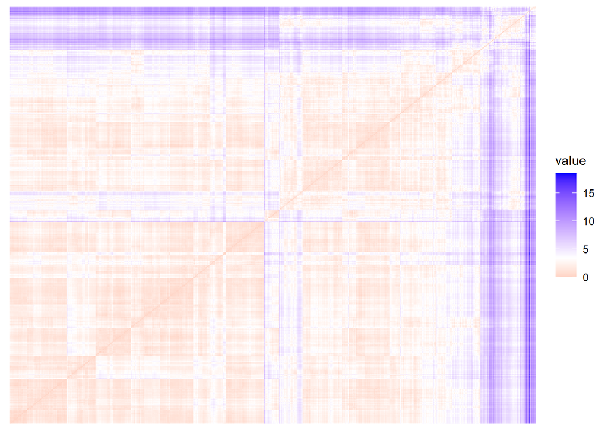

El mapa de calor revela que existen patrones claros en los datos, con al menos tres grupos de observaciones con similitudes internas. Esto refuerza la idea de que el dataset puede dividirse en tres clusters. La presencia de áreas con colores más intensos sugiere que algunas observaciones son más similares entre sí en ciertas características, mientras que otras tienen mayor variabilidad. El dataSet puede ser bueno para representar diferentes tipos de películas en términos de su presupuesto, popularidad y desempeño en taquilla.

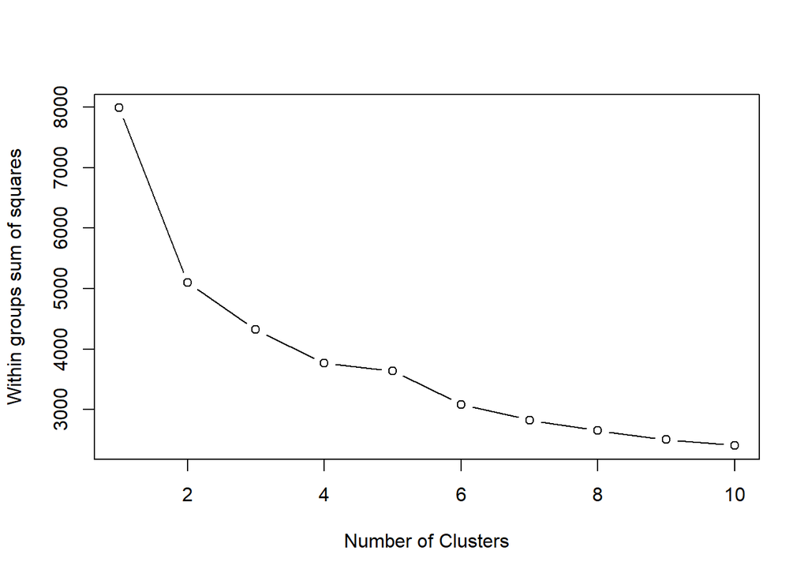

El método del codo sugiere que un número óptimo de clusters es k = 3, ya que en este punto la reducción en la varianza dentro de los clusters deja de ser significativa.

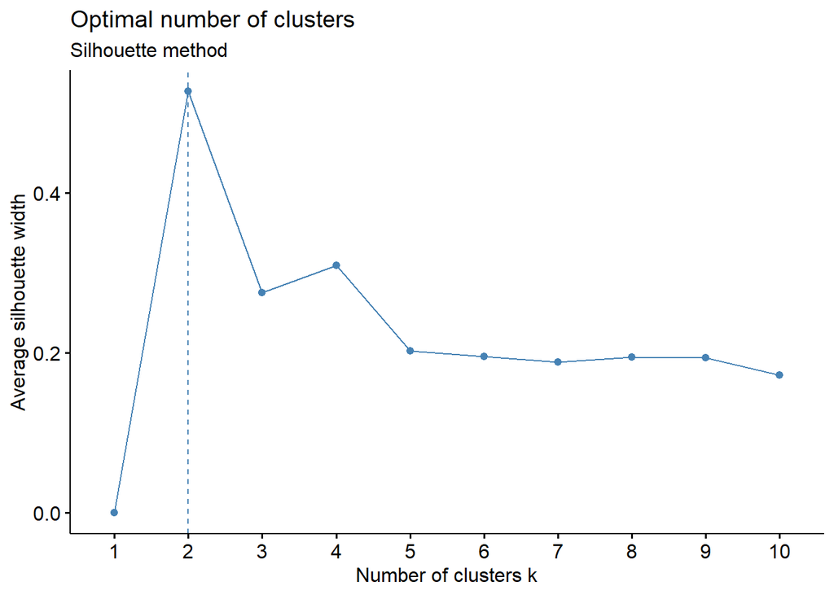

## K means

Antes de empezar con el k mean comprobamos cual k era el mas adecuado para este clustering

### k = 3

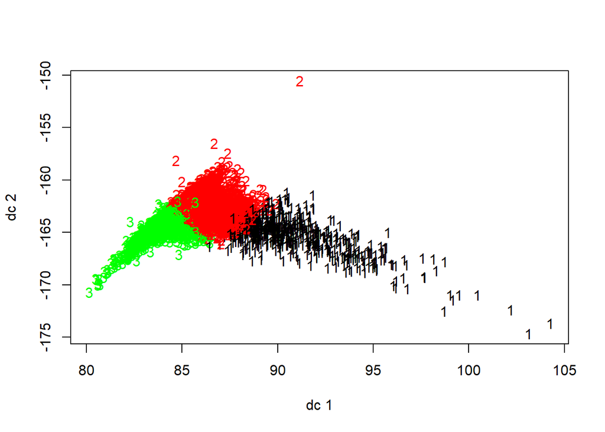

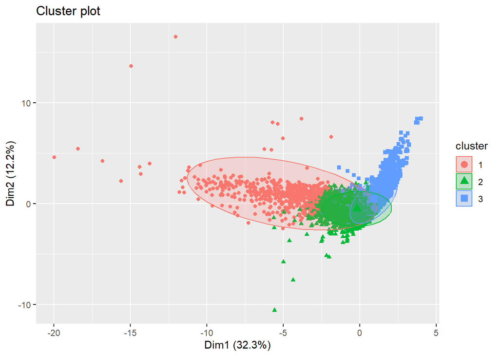

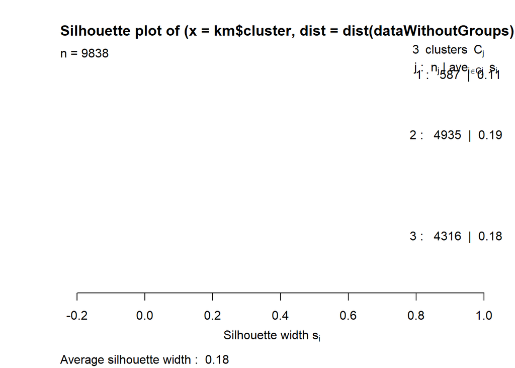

### K = 2

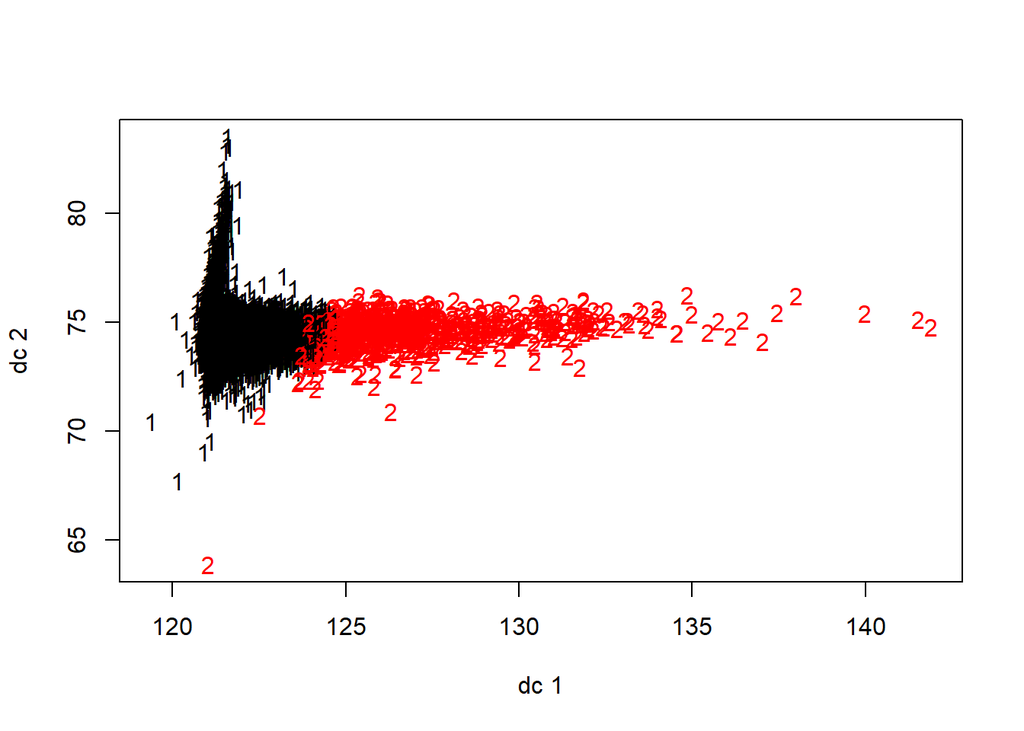

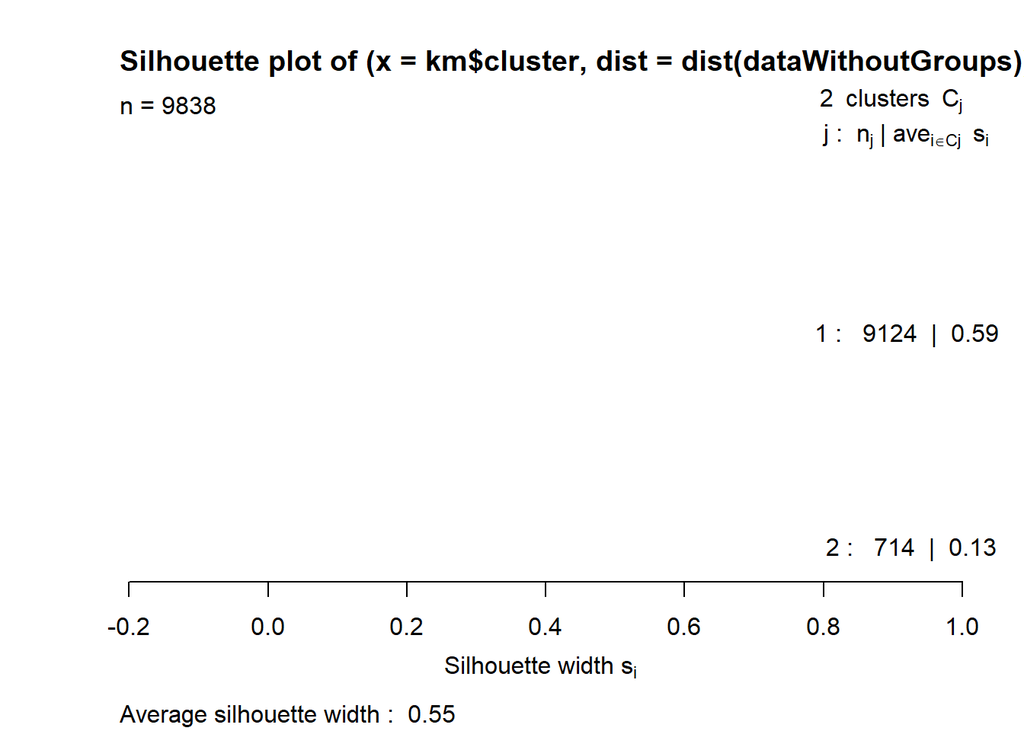

Aunque el método del codo sugirió que k=3 podría ser un punto adecuado, al calcular el índice de silueta encontramos que para k=2 el valor es 0.55, significativamente mayor que el 0.18 obtenido con k=3. Esto indica que los clusters son más compactos y están mejor separados cuando se utilizan dos grupos en lugar de tres. Por esta razón, elegimos k=2, ya que proporciona una segmentación más clara y efectiva de los datos.

## Cluster Jerarquico

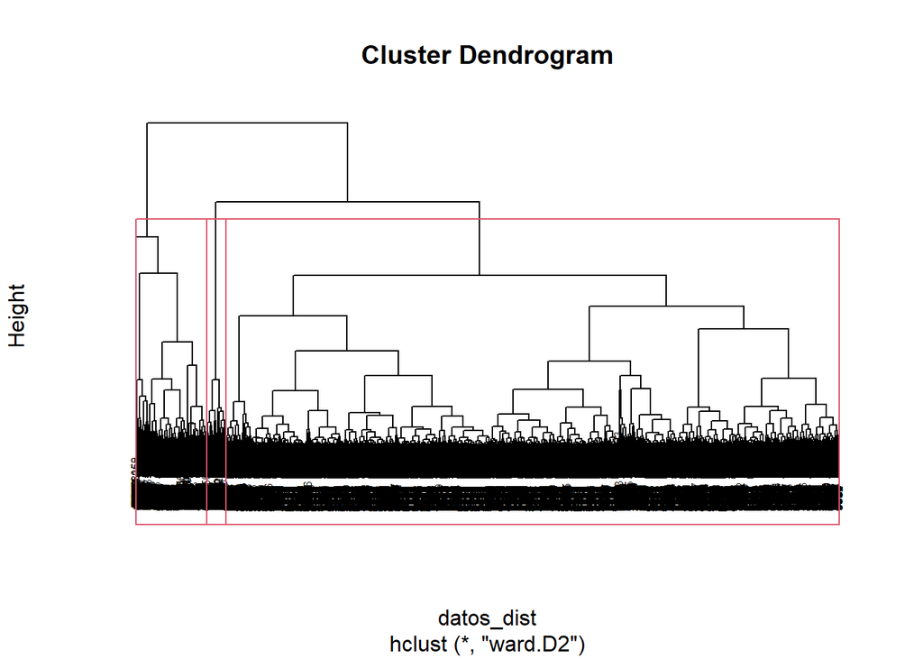

```
## groups
##    1    2    3
## 8575  995  268
```

```
## [1] 0.509389
```

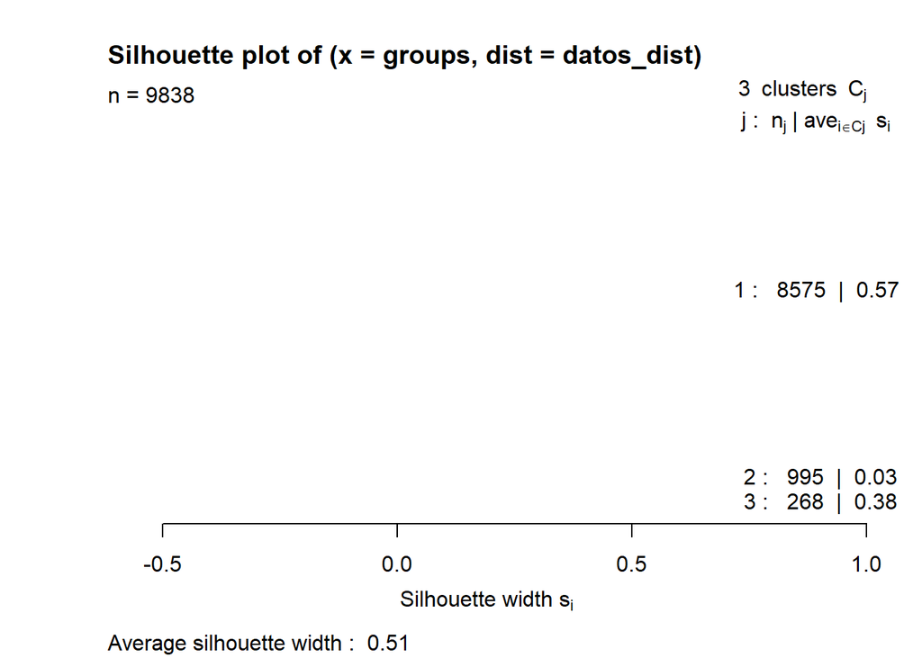

## Interpretacion del clustering

Resumen de las variables con el metodo de k means

| popularity_mean | budget_mean | revenue_mean | runtime_mean |
| --- | --- | --- | --- |
| 48.78458 | 15966730 | 44958998 | 100.0764 |
| 57.73077 | 55790081 | 220130395 | 110.5000 |

Resumen de las variables con el metodo de cluster jerarquico

| popularity_mean | budget_mean | revenue_mean | runtime_mean |
| --- | --- | --- | --- |
| 47.50223 | 15864374 | 44216888 | 99.90915 |
| 58.84922 | 47740370 | 184325690 | 110.31055 |
| 76.28257 | 7372717 | 17966894 | 95.20149 |

K mean por el meotdo de la silueta le quedaba de mejor forma organizarse en 2 grupos y cluster jerarquico por este mismo metodo le quedaba de mejor forma organizarse en 3 grupos.

Teniendo eso en cuenta analizamos procedemos a analizar.

Por lo que se puede observar en el resumen de ambos grupos, los dos metodos tuvieron distribuciones bastante parecidas menos por el presupuesto y los ingresos, los cuales por claras razones de ser 3 y 2 en el cluster jerarquico estan un poco mejor distribuidas.

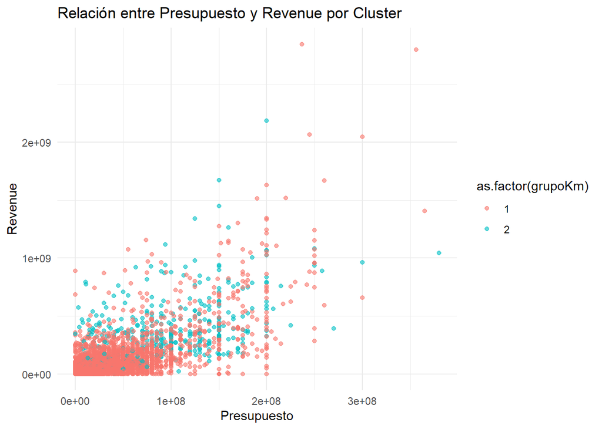

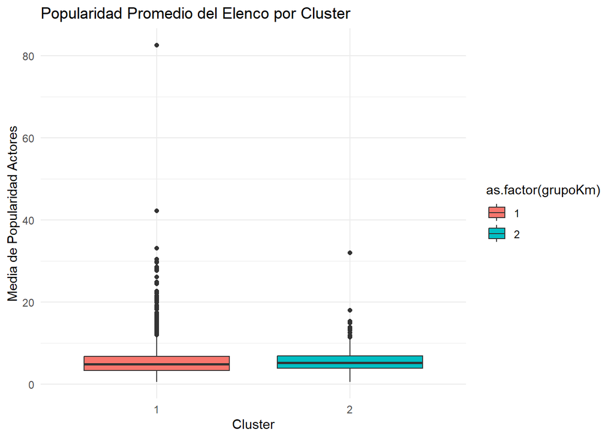

# Analisis por Componentes principales

Para ello primero se requirio de la limpieza del dataset para contar solamente contar con un dataframe de variables cuantitativas. Este sería un ejemplo del Dataset con el que se trabajará el PCA.

Para ello se tomaron solo variables que eran inherentemente cuantitativas, ya que a pesar que las variables cualitativas aunque no se conviertan a un equivalente númerico, no tienen noción de orden y magnitud, y por en no aportando mucho valor al cálculo de componentes.

| popularity | budget | revenue | runtime | genresAmount | voteCount | voteAvg | castMenAmount | castWomenAmount |
| --- | --- | --- | --- | --- | --- | --- | --- | --- |
| 20.880 | 4.0e+06 | 4257354 | 98 | 2 | 2077 | 5.7 | 9 | 15 |
| 9.596 | 2.1e+07 | 12136938 | 110 | 3 | 223 | 6.5 | 9 | 3 |
| 100.003 | 1.1e+07 | 775398007 | 121 | 3 | 16598 | 8.2 | 62 | 5 |
| 134.435 | 9.4e+07 | 940335536 | 100 | 2 | 15928 | 7.8 | 18 | 5 |
| 58.751 | 5.5e+07 | 677387716 | 142 | 3 | 22045 | 8.5 | 48 | 18 |
| 33.589 | 1.5e+07 | 356296601 | 122 | 1 | 9951 | 8.0 | 15 | 22 |

## PCA es aplicable

Acto seguido, es importantes verificar si el PCA será una buena técnica para este conjunto de datos. Empezando por revisar la colinealidad de las variables:

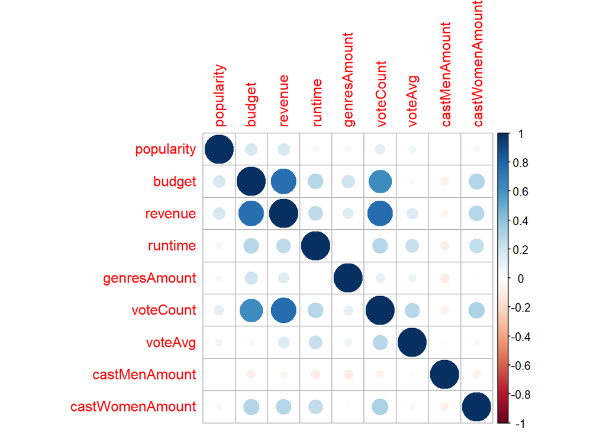

**KMO**

```
## Kaiser-Meyer-Olkin factor adequacy
## Call: KMO(r = as.matrix(PCA_raw_data))
## Overall MSA =  0.74
## MSA for each item =
##      popularity          budget         revenue         runtime    genresAmount
##            0.83            0.76            0.70            0.77            0.62
##       voteCount         voteAvg   castMenAmount castWomenAmount
##            0.76            0.51            0.69            0.86
```

**Esfericidad de Bartlet**

```
## R was not square, finding R from data
```

```
## $chisq
## [1] 21952.59
##
## $p.value
## [1] 0
##
## $df
## [1] 36
```

## Aplicación de PCA

Estas serian las componentes de principales del subset de datos.

```
## [1] 0
```

```
## Standard deviations (1, .., p=9):
## [1] 1.7049488 1.0418268 1.0316224 1.0114821 0.9608926 0.8932974 0.8356471
## [8] 0.5598308 0.4328906
##
## Rotation (n x k) = (9 x 9):
##                         PC1         PC2          PC3          PC4         PC5
## popularity       0.14442911  0.25163202 -0.046325371 -0.546055343  0.77245277
## budget           0.49165068  0.26462152 -0.065942086  0.091715572 -0.05615038
## revenue          0.51634229  0.19533683 -0.124308749  0.002249972 -0.11265397
## runtime          0.28181179 -0.55739929  0.005675743  0.061403136  0.12006918
## genresAmount     0.13279646  0.36462315  0.661119078 -0.168835944 -0.31140796
## voteCount        0.50291645  0.01211703 -0.091180674 -0.033431339 -0.16168200
## voteAvg          0.17315847 -0.57780254  0.203847257 -0.581365134 -0.20248834
## castMenAmount   -0.09308855  0.13214542 -0.687088934 -0.385829772 -0.40577444
## castWomenAmount  0.28667649 -0.18273281 -0.137780490  0.416128762  0.21044219
##                         PC6           PC7         PC8         PC9
## popularity       0.11602919  0.0051548668 -0.06925113  0.02303759
## budget          -0.07985002  0.1707947521  0.69240568  0.39669837
## revenue         -0.22250303 -0.0002660751 -0.03845208 -0.78491993
## runtime          0.26203349  0.7139916875 -0.10761065 -0.04053699
## genresAmount     0.51378232  0.0855564415 -0.12279137 -0.02205061
## voteCount       -0.24013787 -0.1401506521 -0.64205424  0.47097084
## voteAvg         -0.08592753 -0.3658471691  0.27172587 -0.02360236
## castMenAmount    0.42379450  0.0899690091 -0.01537798  0.01818567
## castWomenAmount  0.59444786 -0.5404791353  0.03656837 -0.03419912
```

```
## Importance of components:
##                          PC1    PC2    PC3    PC4    PC5     PC6     PC7
## Standard deviation     1.705 1.0418 1.0316 1.0115 0.9609 0.89330 0.83565
## Proportion of Variance 0.323 0.1206 0.1182 0.1137 0.1026 0.08866 0.07759
## Cumulative Proportion  0.323 0.4436 0.5618 0.6755 0.7781 0.86677 0.94436
##                            PC8     PC9
## Standard deviation     0.55983 0.43289
## Proportion of Variance 0.03482 0.02082
## Cumulative Proportion  0.97918 1.00000
```

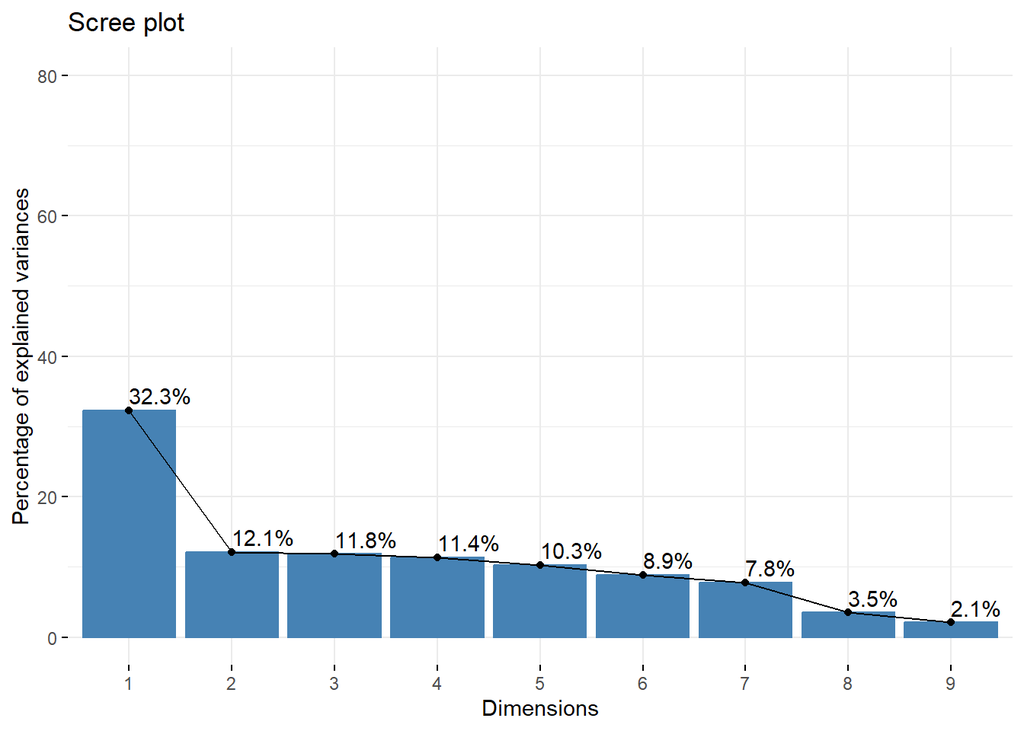

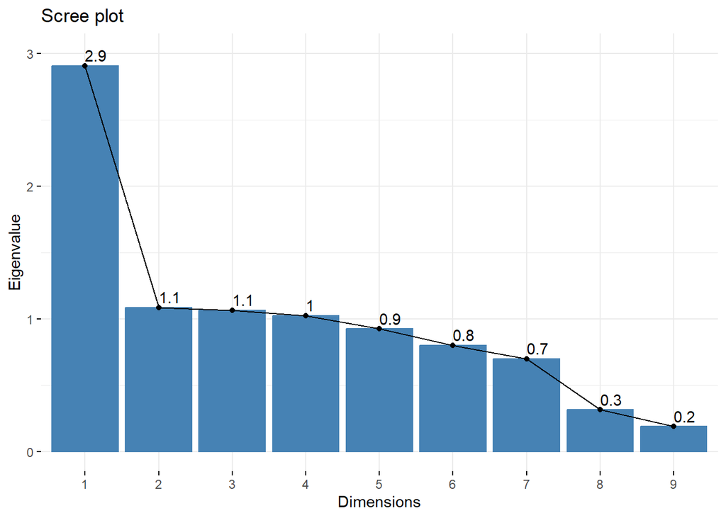

## Interpretación de PSA

El siguiente gráfico muestra vectores proyectos sobre las 2 primeras componentes. Y se puede observar las relaciones descubiertas en pasos anteriorres sobre la covarianza: Las componetnes de presupuesto, y número de votos y ganancias estan muy relacionadas positivamente entre, y bien representadas en la primera dimensión.

También se puede decir algo parecido del tiempo de expiración y el promedio de votos, solo que estos 2 ultimos se encuentran menos representados en la 1 y 2 dimensión.

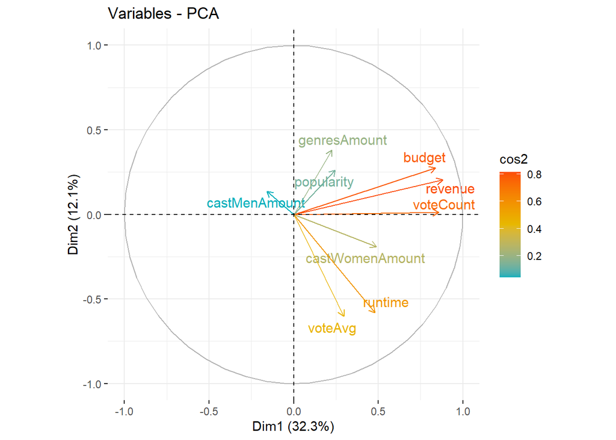